# Time to next new nuclear-weapon state

Spencer Graves

2019-11-18

# Abstract

This article models the time between “first test” of a nuclear weapon by one nation and the next. It uses this model to obtain confidence bounds on the number of nuclear-weapon states decades into the future. A plot of the times between “first tests” of the 9 nuclear powers as of 2019-10-15 suggests a nonhomogeneous [renewal process](https://en.wikipedia.org/wiki/Renewal_theory). For this we use the [`bssm` package](https://www.rdocumentation.org/packages/bssm/versions/0.1.7) to model a series of annual Poisson observations of the number of states conducting a ‘’first test’’ of a nuclear weapon each year, where the log(Poisson mean) follows a [Gaussian random walk](https://en.wikipedia.org/wiki/Random_walk#Gaussian_random_walk) in one dimension.

# Introduction

The plot of times between “first tests” by the world’s nuclear-weapon states as of 2019-05-14 suggests that the process of nuclear proliferation has slowed over time.

(fig:plot) Time between new nuclear nations

```r
library(Ecdat)
```

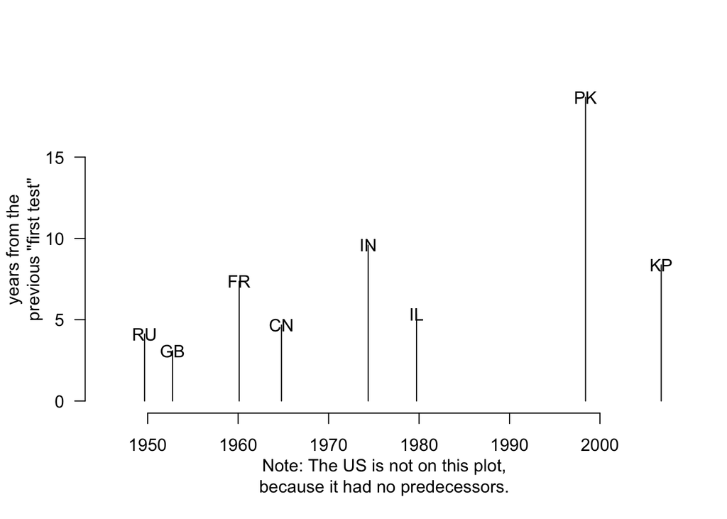

(fig:plot)

```r
data(nuclearWeaponStates)
ymax <- max(
  nuclearWeaponStates$yearsSinceLastFirstTest,
            na.rm=TRUE)
ylim. <- c(0, ymax)
plot(yearsSinceLastFirstTest~firstTest,
     nuclearWeaponStates, type='h',
     xlab='', ylab='', las=1,
     ylim=ylim., bty='n')
#title(
#  'Figure 1. Time between\nnew nuclear nations')
xlab. <- paste(c(
  'Note: The US is not on this plot,',
  'because it had no predecessors.'),
               collapse='\n')
mtext(xlab., 1, 3)
mtext('years from the\nprevious "first test"',
      2, 2)
with(nuclearWeaponStates,
  text(firstTest, yearsSinceLastFirstTest,
       ctry, xpd=TRUE))
```

However, it stretches credibility to suggest that nuclear proliferation has stopped. There were only 5 nuclear-weapon states when the [Treaty on the Non-Proliferation of Nuclear Weapons (NPT, Non-proliferation treaty)](https://en.wikipedia.org/wiki/Treaty_on_the_Non-Proliferation_of_Nuclear_Weapons) entered into force in 1970. When US President [George W. Bush](https://en.wikipedia.org/wiki/George_W._Bush) decried an [“Axis of evil”](https://en.wikipedia.org/wiki/Axis_of_evil) in his State of the Union message, 29 January 2002, there were 8. As this is written 2019-10-15, there are 9. Toon et al. (2007) noted that in 2003 another 32 had sufficient fissile material to make nuclear weapons if they wished.

Moreover, those 32 do NOT include Turkey nor Saudi Arabia. On September 4, 2019, Turkish President Erdogan said it was unacceptable for nuclear-armed states to forbid Turkey from acquiring its own nuclear weapons.[^1] And Saudi Arabia previously announced a desire to develop nuclear weapons “if Iran does.”[^2] This is particularly disturbing, because of the substantial evidence that Saudi Arabia may have been and may still be the primary recruiter and funder of Islamic terrorism.[^3]

This analysis suggests that the number of nuclear-weapon states will continue to grow until either (i) a nuclear war destroys the ability of anyone to make more nuclear weapons, or (ii) the fundamental structure of international relations changes to the point that any nation that perceives an external threat can confidently rely on international law for protection, without a military that might threaten other countries.

This vignette first reviews the data and history on this issue including brief discussions of what might have motivated different nations to pursue nuclear weapons. We then consider modeling these data as a series of annual Poisson observations of the number of states conducting a first test of a nuclear weapon each year, where the log(Poisson mean) follows a [Gaussian random walk](https://en.wikipedia.org/wiki/Random_walk#Gaussian_random_walk) in one dimension. We model these data using the [`ng_bsm` function](https://www.rdocumentation.org/packages/bssm/versions/0.1.8/topics/ng_bsm) in the [`bssm` package](https://www.rdocumentation.org/packages/bssm/versions/0.1.7). This model is estimated using the [`run_mcmc` function](https://www.rdocumentation.org/packages/bssm/versions/0.1.7/topics/run_mcmc), which is further used to extend the 74 years of history of nuclear proliferation available as this is being written in 2019 into predicting another 74 years into the future with [`predict.mcmc_output`](https://www.rdocumentation.org/packages/bssm/versions/0.1.7/topics/predict.mcmc_output).

# What motivated the existing nuclear-weapon states to develop this capability?

Ellsberg (2017) noted that every US president since [Truman (president: 1945-1953)](https://pl.wikipedia.org/wiki/Harry_Truman) considered the use of nuclear weapons. [With the possible exception of Ford, all threatened to use them, sometimes publicly, sometimes in secret.](https://en.wikipedia.org/wiki/Daniel_Ellsberg#The_Doomsday_Machine) Countries threatened include the Soviet Union (now Russia), the People’s Republic of China, Iraq, Iran, Libya, India, and North Korea.

One might therefore understand the motivation of North Korea to accelerate their nuclear program in the early 2000s after hearing themselves along with Iran and Iraq described as the [“Axis of evil”](https://en.wikipedia.org/wiki/Axis_of_evil) by US President [George W. Bush](https://en.wikipedia.org/wiki/George_W._Bush) and after then seeing Iran repeatedly threatened and Iraq invaded with [estimated deaths ranging from over 100,000 to over a million](https://en.wikipedia.org/wiki/Iraq_War) out of a population in 2016 of roughly 37 million. Indeed, any reasonable person might understand the eagerness of North Korean leaders for something that could protect them from similar threats.

Similar logic might explain why Soviet leaders might have felt a need to defend themselves from nuclear coercion after having been invaded by the US and other countries trying to put the Tsar back in power after World War I. The United Kingdom and France likely felt nuclear threats from the Soviet Union.

China faced nuclear threats from the US regarding Korea and the Taiwan Strait. India faced major threats from China,[^4] Pakistan from India,[^5] and Israel from its neighbors.[^6]

Beyond this, the inspector general of the US Department of Energy concluded in 2009 (in its most recent public accounting) that enough highly enriched uranium was missing from US inventories to make at least five nuclear bombs comparable to those that destroyed substantial portions of Hiroshima and Nagasaki in 1945. Substantially more weapons-grade materials may be missing in other countries, especially Russia.[^7]

The knowledge and other materials required to make such weapons is sufficiently available that any nation posessing sufficient fissile material could make such weapons in a relatively short order.

More generally the history of US belicosity includes [invading Canada in 1812](https://www.history.com/news/how-u-s-forces-failed-to-conquer-canada-200-years-ago)[^8] and [numerous other foreign interventions](https://en.wikipedia.org/wiki/Foreign_interventions_by_the_United_States) including invading Afghanistan in 2001, and Iraq in 2003, plus continued threats against Iran, North Korea, and now Venezuela. This history might help people understand how leaders in many countries may be concerned about their own security if they fail to do what the US demands of them. The [extra-judicial execution of Osama bin Laden and four others in his household by SEAL Team 6](https://en.wikipedia.org/wiki/Death_of_Osama_bin_Laden) on 2011-05-02 has reportedly increased the risks that a Pakistani nuclear weapon might be stolen by Islamic terrorists intent on retaliating against the US for its interventions in Pakistan and neighboring countries.[^9]

*The September 11th attacks*

*might have been a mushroom cloud.*

In this context, declassified US government documents establish that in the 1980s, when the US was clandestinely supporting the Contra war against Nicaragua in violation of US law, it was also [secretly helping the Pakistani nuclear program in violation of US law. This was done to secure Pakistani cooperation with US support for anti-Soviet resistance in Afghanistan](https://www.wilsoncenter.org/publication/new-documents-spotlight-reagan-era-tensions-over-pakistani-nuclear-program).[^10]

Without this, “the nuclear weapons programmes of Iran, Libya and North Korea - which British and American intelligence now acknowledge were all secretly enabled by Pakistan - would never have got off the ground,” according to [Robert Gallucci](https://en.wikipedia.org/wiki/Robert_Gallucci), special adviser on WMDs to President Clinton.[^11]

Similar comments have been made by Richard Barlow, a CIA analyst reported these questionable activities to a committee of the US House.[^12]

And now the US is helping Saudi Arabia obtain nuclear power, in spite of the evidence that [the Saudi government including members of the Saudi royal family were involved in preparations for 9-11 at least as early as 1999](https://en.wikipedia.org/wiki/The_28_pages) and their [on-going support for Al Qaeda in Yemen, reported as recently as 2019](https://en.wikipedia.org/wiki/Saudi_Arabian-led_intervention_in_Yemen).

Unless there is some fundamental change in the structure of international relations, it seems unwise to assume that there will not be more nuclear nations in the future, with the time to the next “first test” of a nuclear weapon following a probability distribution consistent with the previous times between “first tests” of nuclear weapons by new nuclear-weapon states.

# Exponential time between Poisson ‘first tests’

Figure 1 suggests that the time between ‘first tests’ of succeeding nuclear-weapon states is increasing. Let’s redo that plot with a log scale on the y axis:

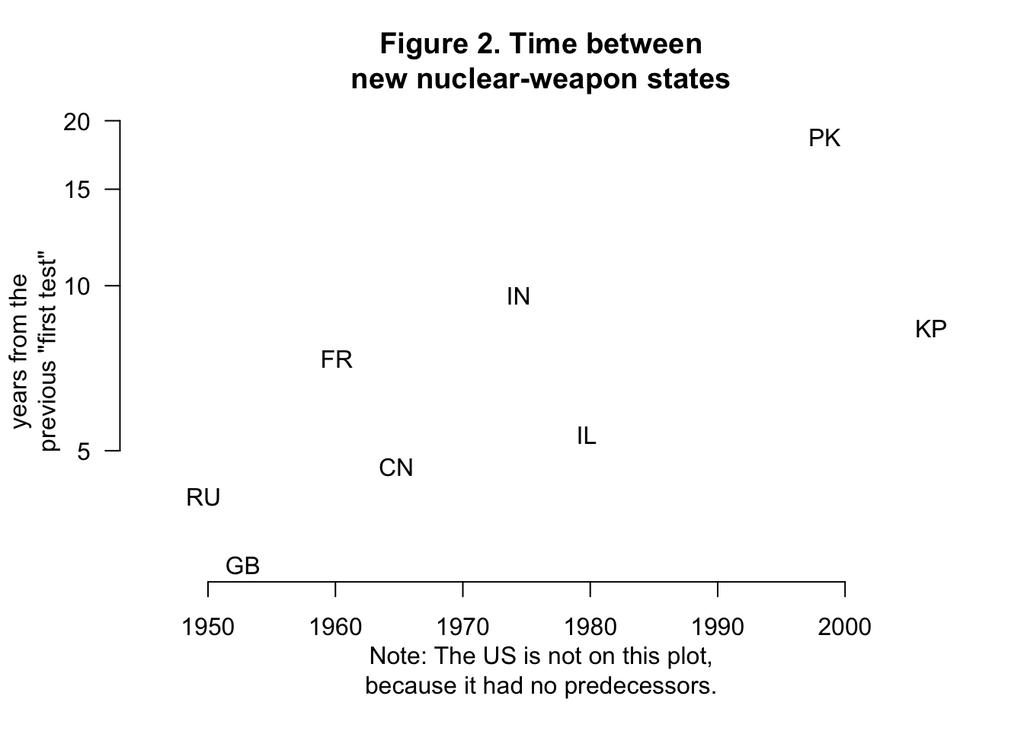

```r
library(Ecdat)
plot(yearsSinceLastFirstTest~firstTest,
     nuclearWeaponStates, type='n',
     xlab='', ylab='', las=1, log='y',
     bty='n')
title(
  'Figure 2. Time between\nnew nuclear-weapon states')
mtext('Note: The US is not on this plot,\nbecause it had no predecessors.', 1, 3)
mtext('years from the\nprevious "first test"', 2, 2)

with(nuclearWeaponStates,
  text(firstTest, yearsSinceLastFirstTest,
       ctry, xpd=TRUE))
```

Figures 1 and 2 seem consistent with the following:

- Time between events might be exponentially distributed but with a hazard rate that varies over time. [Recall that the [hazard rate](https://en.wikipedia.org/wiki/Survival_analysis#Hazard_function_and_cumulative_hazard_function) for the exponential distribution is constant: $h(t) = (-d/dt \log S(t)) = \lambda$, writing the exponential survival function as $S(t) = \exp(-\lambda t)$.] This is consistent with the apparent increase in the time to the next “first test” by a new nuclear-weapon state. However, the time between such “first tests” might decrease in the future if more states began to perceive greater threats from other nations.
- Log hazard that behaves like a [“Wiener process” (also called a “Brownian motion”)](https://en.wikipedia.org/wiki/Wiener_process), which means that the variance of the increments in log(hazard) between “first tests” is proportional to the elapsed time.
- The likelihood for the observed times between “first tests” is an exponential density with an exponential survival function for the censored observation from the last “first test” to the present.

The [`bssm` package](https://www.rdocumentation.org/packages/bssm/versions/0.1.7) provides a reasonable framework for modeling this using its [`ng_bsm` function](https://www.rdocumentation.org/packages/bssm/versions/0.1.7/topics/ng_bsm). This function allows us to model a normal random walk in log(Poisson mean) of the number of “first tests” each year with the log(Poisson mean). This uses the fact that [the probability distribution of the time between events in a Poisson point process is exponential](https://en.wikipedia.org/wiki/Exponential_distribution).

For the first argument `y` in `ng_bsm`, we will use the number of “first tests” each year starting with 1946, the year after the “first test” by the US. We’ll use the [`lubridate` package](https://lubridate.tidyverse.org/) for dates. The first thing we want is the current year. We get that starting with [`today`](https://www.rdocumentation.org/packages/lubridate/versions/1.7.4/topics/today):

```r
library(lubridate)
(Today <- today())
```

```
## [1] "2019-11-24"
```

From this we get the year:

```r
(currentYear <- year(Today))
```

```
## [1] 2019
```

Let’s include an observation for the current year only if it’s more than 6 months since January 1 and since the last “first test”:

```r
if((month(Today)<7) ||
   (difftime(Today,
          tail(nuclearWeaponStates$firstTest, 1),
          units = 'days')<(366/2)))
      currentYear <- (year(Today)-1)
```

Start after the year of the first test of a nuclear weapon:

```r
firstTstYr <- year(nuclearWeaponStates$firstTest)
(firstYear <- firstTstYr[1])
```

```
## [1] 1945
```

Now let’s create a vector of the number of “firstTests” by year:

```r
(nYrs <- currentYear - firstYear)
```

```
## [1] 74
```

```r
firstTests <- ts(rep(0, nYrs), firstYear+1)
firstTstYrSinceFirst <- firstTstYr - firstYear
firstTests[firstTstYrSinceFirst] <- 1

library(tibble)
#(FirstTsts <- tibble(Year=time(firstTests),
#      nFirstTests=as.numeric(firstTests)))
(FirstTsts <- tibble(Year=time(firstTests),
      nFirstTests=firstTests))
```

```
## # A tibble: 74 x 2
##     Year nFirstTests
##    <dbl>       <dbl>
##  1  1946           0
##  2  1947           0
##  3  1948           0
##  4  1949           1
##  5  1950           0
##  6  1951           0
##  7  1952           1
##  8  1953           0
##  9  1954           0
## 10  1955           0
## # … with 64 more rows
```

Add `ctry` to this tibble:

```r
Ctry <- rep('', nYrs)
Ctry[firstTstYrSinceFirst] <-
        nuclearWeaponStates$ctry[-1]
FirstTests <- cbind(FirstTsts, ctry=Ctry)
```

We need the other arguments of [`ng_bsm`](https://www.rdocumentation.org/packages/bssm/versions/0.1.7/topics/ng_bsm). Many of the arguments seem fairly straightforward. This is not true for `P1` = prior variance of `a1`. For this we use the [“Delta method”](https://en.wikipedia.org/wiki/Delta_method) applied to `a[t] = log(mu[t])`: For the [Poisson distribution](https://en.wikipedia.org/wiki/Poisson_distribution), the variance is equal to the mean. And the first derivative of `log(mu)` is `1/mu`.

Based on the above plot, let’s use only the first 7 years to estimate a prior for `a1`: These years 1946:1952 include the first tests by RU and GB:

```r
(mu <- mean(FirstTests$nFirstTests[1:7]))
```

```
## [1] 0.2857143
```

```r
(a1 <- log(mu))
```

```
## [1] -1.252763
```

```r
(P1 <- mu / (mu^2))
```

```
## [1] 3.5
```

We also need a prior for `sd_level`, the migration standard deviation. For this it seems sensible to start by noting that the level, alpha = log(Poisson mean), migrated from log(2/7) at the start of the period since the first test by the US to log(2/30), noting that it’s been 30 years since the [“Vela Incident”](https://en.wikipedia.org/wiki/Vela_incident), which is widely believed to have been a joint test of a nuclear weapon by Israel and South Africa. It might be plausible to assume that the difference between these numbers is one standard deviation of the sum of 74 independent normal deviatiates with a standard deviation of `sd_level`. This assumption gives us the following estimate of `sd_level`:

```r
(sd_lvl <- (abs(log(2/7)-log(2/30)) / sqrt(74)))
```

```
## [1] 0.1691737
```

```r
library(bssm)
firstTstsMdl <- ng_bsm(FirstTests$nFirstTests,
    sd_level=halfnormal(sd_lvl, 10*sqrt(P1)),
    a1=a1, P1=P1, distribution='poisson')
str(firstTstsMdl)
```

```
## List of 23
##  $ y                  : Time-Series [1:74] from 1946 to 2019: 0 0 0 1 0 0 1 0 0 0 ...
##  $ Z                  : num [1, 1] 1
##   ..- attr(*, "dimnames")=List of 2
##   .. ..$ : chr "level"
##   .. ..$ : NULL
##  $ T                  : num [1, 1, 1] 1
##   ..- attr(*, "dimnames")=List of 3
##   .. ..$ : chr "level"
##   .. ..$ : chr "level"
##   .. ..$ : NULL
##  $ R                  : num [1, 1, 1] 0.169
##   ..- attr(*, "dimnames")=List of 3
##   .. ..$ : chr "level"
##   .. ..$ : NULL
##   .. ..$ : NULL
##  $ a1                 : Named num -1.25
##   ..- attr(*, "names")= chr "level"
##  $ P1                 : num [1, 1] 3.5
##   ..- attr(*, "dimnames")=List of 2
##   .. ..$ : chr "level"
##   .. ..$ : chr "level"
##  $ phi                : num 1
##  $ u                  : num [1:74] 1 1 1 1 1 1 1 1 1 1 ...
##  $ xreg               : num[0 , 0 ]
##  $ coefs              : num(0)
##  $ obs_intercept      : num [1, 1] 0
##  $ state_intercept    : num [1, 1] 0
##  $ slope              : logi FALSE
##  $ seasonal           : logi FALSE
##  $ noise              : logi FALSE
##  $ period             : num 1
##  $ fixed              : int [1:3] 0 1 1
##  $ distribution       : chr "poisson"
##  $ initial_mode       : Time-Series [1:74] from 1946 to 2019: -2.3 -2.3 -2.3 0 -2.3 ...
##  $ prior_distributions: num 1
##  $ prior_parameters   : num [1:2, 1] 18.7 NA
##  $ theta              : Named num 0.169
##   ..- attr(*, "names")= chr "sd_level"
##  $ phi_est            : logi FALSE
##  - attr(*, "class")= chr [1:2] "ng_bsm" "ngssm"
```

`firstTstsMdl` is an object of class `"ng_bsm" "ngssm"`.

# Parameter estimation

The help page for the [`ng_bsm` function](https://www.rdocumentation.org/packages/bssm/versions/0.1.7/topics/ng_bsm) includes an example using the [`run_mcmc` function](https://www.rdocumentation.org/packages/bssm/versions/0.1.7/topics/run_mcmc) to produce simulations from which desired parameters are estimated. Other examples included in the [`bssm` vignette](https://www.rdocumentation.org/packages/bssm/versions/0.1.8/vignettes/bssm.Rmd) provide examples estimating parameters in a model coded using both the `bsm` and `lg_ssm` functions.

```r
set.seed(2)
firstTstsSim <- run_mcmc(firstTstsMdl,
          nsim_states=1, n_iter = 5000)
firstTstsSim
```

```
##
## Call:
## run_mcmc.ng_bsm(object = firstTstsMdl, n_iter = 5000, nsim_states = 1)
##
## Iterations = 2501:5000
## Thinning interval = 1
## Length of the final jump chain = 648
##
## Acceptance rate after the burn-in period:  0.2588
##
## Summary for theta:
##
##               Mean        SD       SE-IS       SE-AR         SE
## sd_level 0.1719822 0.1696338 0.007759485 0.007765479 0.01097781
##
## Effective sample sizes for theta:
##
##            ESS-IS   ESS-AR
## sd_level 209.1486 477.1864
##
## Summary for alpha_75:
##
##            Mean        SD      SE-IS      SE-AR       SE
## level -2.581278 0.8716557 0.04201773 0.04205019 0.059445
##
## Effective sample sizes for alpha_75:
##
##         ESS-IS   ESS-AR
## level 330.4752 429.6888
##
## Run time:
##    user  system elapsed
##   1.283   0.007   1.295
```

```r
class(firstTstsSim)
```

```
## [1] "mcmc_output"
```

```r
str(firstTstsSim)
```

```
## List of 15
##  $ alpha          : num [1:75, 1, 1:648] -1.45 -1.82 -1.83 -1.68 -1.84 ...
##   ..- attr(*, "dimnames")=List of 3
##   .. ..$ : NULL
##   .. ..$ : chr "level"
##   .. ..$ : NULL
##  $ theta          : num [1:648, 1] 0.24618 0.03774 0.01681 0.00816 0.06173 ...
##   ..- attr(*, "dimnames")=List of 2
##   .. ..$ : NULL
##   .. ..$ : chr "sd_level"
##  $ weights        : num [1:648, 1] 1 1 1 1 1 1 1 1 1 1 ...
##  $ counts         : num [1:648, 1] 2 2 1 6 5 2 1 5 3 1 ...
##  $ acceptance_rate: num 0.259
##  $ S              : num [1, 1] 4.57
##   ..- attr(*, "dimnames")=List of 2
##   .. ..$ : chr "sd_level"
##   .. ..$ : chr "sd_level"
##  $ posterior      : num [1:648, 1] 0.00 9.19e-322 0.00 2.19e-314 9.91e-320 ...
##  $ n_iter         : num 5000
##  $ n_burnin       : num 2500
##  $ n_thin         : num 1
##  $ mcmc_type      : chr "is2"
##  $ output_type    : int 1
##  $ call           : language run_mcmc.ng_bsm(object = firstTstsMdl, n_iter = 5000, nsim_states = 1)
##  $ seed           : int 794080207
##  $ time           : 'proc_time' Named num [1:5] 1.283 0.007 1.295 0 0
##   ..- attr(*, "names")= chr [1:5] "user.self" "sys.self" "elapsed" "user.child" ...
##  - attr(*, "class")= chr "mcmc_output"
##  - attr(*, "model_type")= chr "ng_bsm"
##  - attr(*, "ts")=List of 3
##   ..$ start    : num [1:2] 1946 1
##   ..$ end      : num [1:2] 2019 1
##   ..$ frequency: num 1
```

We see that `dim(firstTstsSim$alpha)` is 75 by 1 by a number close to 645, depending on the seed of the random number generator. The first dimension (75) is the length of the simulated time series from the year after the first test in 1945 to 2020, the year after the end of the input time series. The second dimension is the dimensionality of the state vector, which is 1 in this case. The third is the number of simulated trajectories actually retained, being a number like 645.

With this particular simulation, we get:

```r
(nAcceptedComputed <- with(firstTstsSim,
      acceptance_rate * (n_iter - n_burnin) ))
```

```
## [1] 647
```

```r
dim(firstTstsSim$alpha)[3]
```

```
## [1] 648
```

Let’s look at the estimated parameter, `theta`, being the unknown standard deviation of the migration rate in log(Poisson mean):

```r
theta <- expand_sample(firstTstsSim, "theta")
```

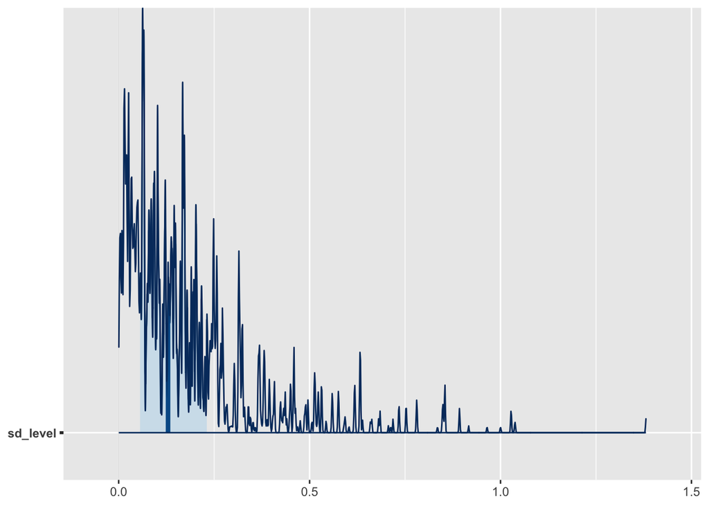

```r
library(bayesplot)
mcmc_areas(theta, bw=0.001)
```

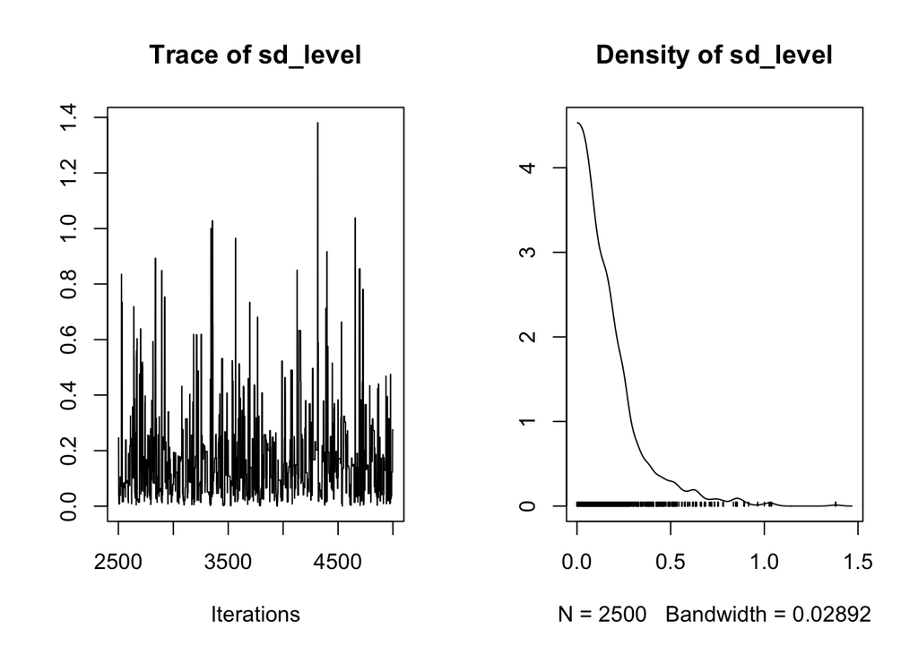

```r
plot(theta)
```

```r
summary(theta)
```

```
##
## Iterations = 2501:5000
## Thinning interval = 1
## Number of chains = 1
## Sample size per chain = 2500
##
## 1. Empirical mean and standard deviation for each variable,
##    plus standard error of the mean:
##
##           Mean             SD       Naive SE Time-series SE
##       0.171982       0.169668       0.003393       0.008303
##
## 2. Quantiles for each variable:
##
##     2.5%      25%      50%      75%    97.5%
## 0.008042 0.055958 0.129280 0.230783 0.632361
```

This is the posterior distribution of the standard deviation of the migration rate in the log(Poisson mean).

```r
level <- expand_sample(firstTstsSim, "alpha",
            times=c(1:3, 10, 25, 50, 65, 73:75))
str(level)
```

```
## List of 1
##  $ level: num [1:2500, 1:10] -1.45 -1.45 -2.53 -2.53 -1.9 ...
##   ..- attr(*, "dimnames")=List of 2
##   .. ..$ : NULL
##   .. ..$ : chr [1:10] "1" "2" "3" "10" ...
##  - attr(*, "mcpar")= num [1:3] 2501 2501 1
##  - attr(*, "class")= chr "mcmc"
```

This is a list of length 1, because this model has a unidimensional state vector. `level$level` gives 10 sample times from each of 2500 trajectories of length 75, one more than the length of the time series used to fit `firstTstsMdl`.

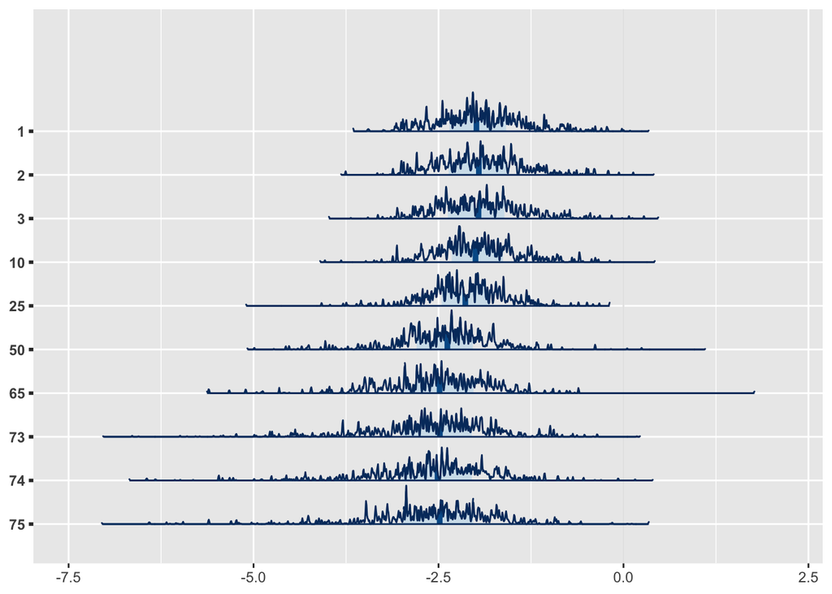

```r
mcmc_areas(level, bw=0.005)
```

The bw (bandwidth) = 0.005 was copied from an example in the [`bssm` vignette](https://www.rdocumentation.org/packages/bssm/versions/0.1.8/vignettes/bssm.Rmd). The image here suggests that’s too small. In experimenting with this parameter, it seemed that bw = 0.1 still showed artifacts that were not replicated between different time periods, while bw = 0.3 did not show some features that were replicated between 70, 71, …, 75 with bw = 0.2. Therefore, I decided to use the latter:

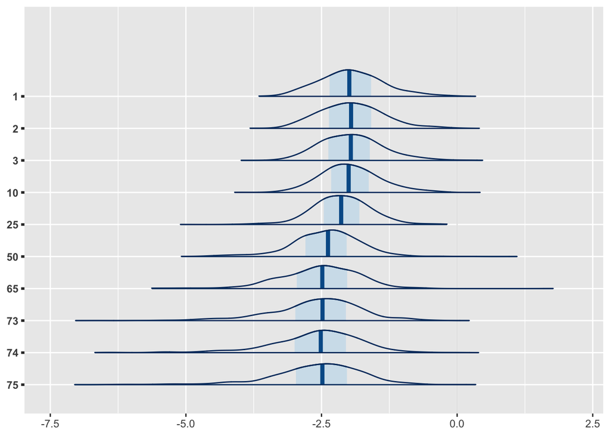

```r
mcmc_areas(level, bw=0.2)
```

These distributions display the decline we expected in the median over time with greater uncertainty at the beginning and the end, again as we expected. The last few distributions show a negative skew. Might that suggest that in this case, the absence of evidence (i.e., that there have been no “first tests” since 2006) may be some evidence of absence?

Let’s look at the trend over the entire period. The [`bssm` vignette](https://www.rdocumentation.org/packages/bssm/versions/0.1.8/vignettes/bssm.Rmd) uses the [`summary.mcmc_output` function](https://www.rdocumentation.org/packages/bssm/versions/0.1.8/topics/summary.mcmc_output) for this. That computes means and standard deviations for parameters estimated and the trajectories of the state vector. However, we will want to compute the [`cumsum`](https://www.rdocumentation.org/packages/base/versions/3.6.1/topics/cumsum) of the Poisson means; for that we will work directly with `expand_sample(firstTstsSim, "alpha")`.

First, we plot the normal approximate confidence intervals with those estimated directly from the quantiles of the MCMC simulations.

```r
firstTstsSum <- summary(firstTstsSim)
lvl <- firstTstsSum$states$Mean[, 1]
lwr <- lvl - 1.96*firstTstsSum$states$SD[, 1]
upr <- lvl + 1.96*firstTstsSum$states$SD[, 1]
vlu <- cbind(lvl, lwr, upr)
VLU <- exp(vlu)

firstTstsSims <- expand_sample(firstTstsSim,
                               'alpha')
```

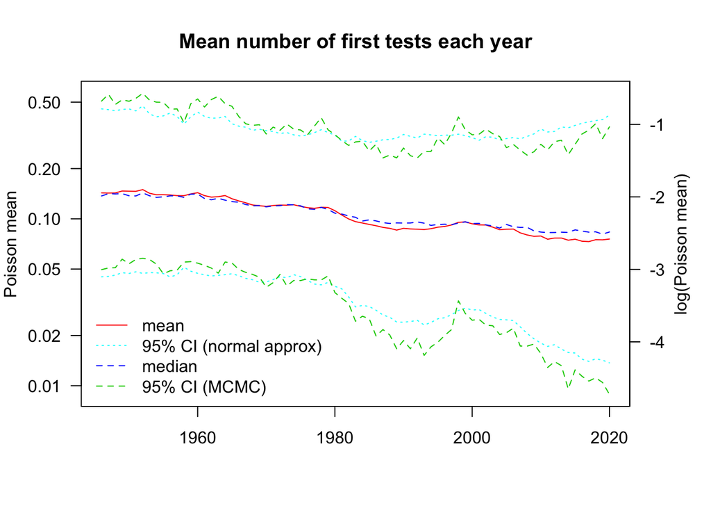

```r
firstTstsQ <- apply(firstTstsSims$level, 2,
        quantile, probs=c(.025, .5, .975))
firstTstsQlog <- ts(t(firstTstsQ),
                    firstYear+1)
firstTstsQuant <- exp(firstTstsQlog)

op <- par(mar=c(5,4,4,4))
ts.plot(VLU, firstTstsQuant,
    col=c(2, 5, 5, 3, 4, 3),
    lty=c(1, 3, 3, 2, 2, 2), log='y',
    gpars=list(las=1), xlab='',
    ylab='Poisson mean',
    main=paste('Mean number of first tests',
               'each year') )

# add a scale for log(Poisson mean)
lvlLims <- range(lwr, upr, firstTstsQ)
lvlLogTicks <- pretty(lvlLims)
axis(4, exp(lvlLogTicks), lvlLogTicks,
     las=1)
mtext('log(Poisson mean)', 4, 2)
legend('bottomleft',
  legend=c('mean',
    '95% CI (normal approx)',
    'median',
    '95% CI (MCMC)'),
  col=c(2, 5, 4, 3),
  lty=c(1, 3, 2, 2), bty='n')
```

```r
par(op)
```

The reciprocal of the Poisson mean in a context like this is the mean time (number of years) to the next event, being the expected number of years to the next “first test” by a new nuclear-weapon state. (If the Poisson mean were constant, [the probability distribution of the time to the next event would be exponential](https://en.wikipedia.org/wiki/Exponential_distribution).)

I’d like to superimpose the actual data from `nuclearWeaponStates` as plotted above on a log scale. However, the dates above are of class `Date`, which are numbers of days since 1970-01-01. However, for this plot the horizontal axis is in numbers of years. For this, we use column `firstTestYr` rather than `firstTest`. The numbers are essentially the same, except that `firstTest` is of class “Date”, being numbers of days since 1970-01-01, while `firstTestYr` gives essentially the same number in years and fractions in the [Common Era (CE)](https://en.wikipedia.org/wiki/Common_Era#History_of_the_use_of_the_CE/BCE_abbreviation).

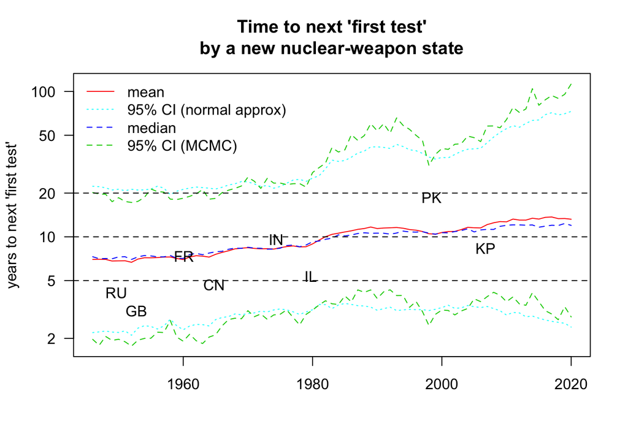

```r
mainExp <- paste("Time to next",
    "'first test'\nby a new",
    "nuclear-weapon state")

ts.plot(1/VLU, 1/firstTstsQuant,
    col=c(2, 5, 5, 3, 4, 3),
    lty=c(1, 3, 3, 2, 2, 2), log='y',
    gpars=list(las=1), xlab='',
    ylab="years to next 'first test'",
    main=mainExp)

legend('topleft',
  legend=c('mean',
    '95% CI (normal approx)',
    'median',
    '95% CI (MCMC)'),
  col=c(2, 5, 4, 3),
  lty=c(1, 3, 2, 2), bty='n')
abline(h=c(5, 10, 20), lty=2)

# plot actual points

with(nuclearWeaponStates,
  text(firstTestYr, yearsSinceLastFirstTest,
       ctry, xpd=TRUE))
```

```r
1/VLU[1, ]
```

```
##       lvl       lwr       upr
##  6.989232 22.267910  2.193711
```

```r
1/tail(VLU, 1)
```

```
##            lvl      lwr      upr
## [75,] 13.21401 72.94625 2.393681
```

```r
apply(1/VLU, 2, quantile,
      probs=c(0, .025, .5, .975, 1))
```

```
##             lvl      lwr      upr
## 0%     6.681997 19.49702 2.103006
## 2.5%   6.831072 20.74423 2.196750
## 50%   10.396775 33.03420 3.018407
## 97.5% 13.454610 70.47263 3.424635
## 100%  13.690538 72.94625 3.482941
```

This seems consistent with the plot of the data above: There were 8 ‘first tests’ by a new nuclear-weapon state in the 74 years since the first test by the US, which had no predecessor. If the mean were constant, it would be 74 / 8 = 9.25 years between ‘first tests’, which seems consistent with the plot.

This plot displays an estimated mean time to the next ‘first test’ starting around 7 years and increasing after 1960 to over 13 years, on average.

It seems somewhat surprising that the line doesn’t go between RU and GB and between FR and CN. However, the arguments that should affect that, `a1`, `P1`, and `sd_level`, were set at levels that would support this.

Apart from that, these estimates overall seem plausible.

# Cumulative number of nuclear-weapon states

What about the cumulative number of nuclear-weapon states? This should be [`cumsum(exp(alpha))`](https://www.rdocumentation.org/packages/base/versions/3.6.1/topics/cumsum), adding 1 for the US.

However, we cannot get confidence limits on the `cumsum` by summing the individual confidence limits, for the same reason that the standard deviation of a sum of random variables is generally not the sum of their standard deviations. We need to compute the mean and quantiles of the (`n_iter - n_burnin`) simulations retained after burn-in for each simulated year:

```r
lvlAll <- expand_sample(firstTstsSim, "alpha")
str(lvlAll)
```

```
## List of 1
##  $ level: num [1:2500, 1:75] -1.45 -1.45 -2.53 -2.53 -1.9 ...
##   ..- attr(*, "dimnames")=List of 2
##   .. ..$ : NULL
##   .. ..$ : chr [1:75] "1" "2" "3" "4" ...
##  - attr(*, "mcpar")= num [1:3] 2501 2501 1
##  - attr(*, "class")= chr "mcmc"
```

```r
lvlEnew <- ts(exp(t(lvlAll$level)), firstYear+1)
str(lvlEnew)
```

```
##  Time-Series [1:75, 1:2500] from 1946 to 2020: 0.234 0.163 0.161 0.186 0.159 ...
##  - attr(*, "dimnames")=List of 2
##   ..$ : NULL
##   ..$ : NULL
```

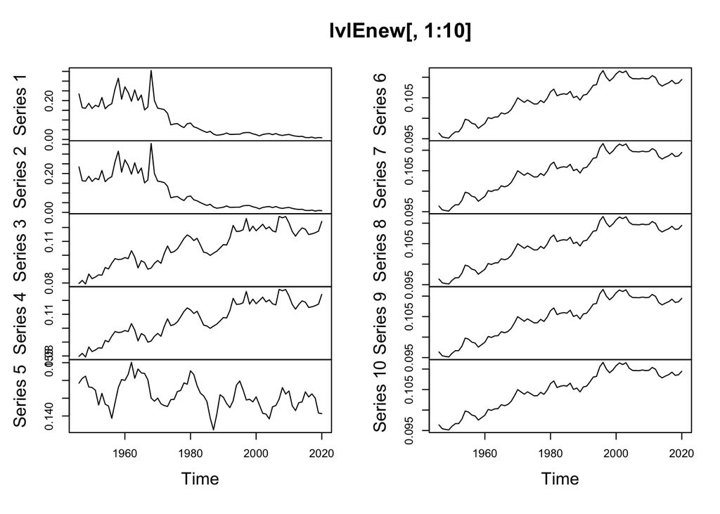

```r
plot(lvlEnew[, 1:10])
```

This shows something of how the `bssm` MCMC algorithm works: A visual inspection of one simulation suggested that the first 10 of the 2500 simulated series include only 4 unique simulations replicated 2, 2, 1, and at least 5 times, which matches `firstTstsSim$counts[1:4]`:

```r
firstTstsSim$counts[1:5]
```

```
## [1] 2 2 1 6 5
```

`str(firstTstsSim)` above showed that “Length of the final jump chain = 648” for one simulation.

The `cumsum` of each simulation in `lvlEnew` represents the simulated expected number of new nuclear-weapon states since the US became the first in 1945. Add one to get the expected total number of nuclear-weapon states over time in each of the 2500 simulations:

```r
str(lvlEnuc2 <- apply(lvlEnew, 2, cumsum))
```

```
##  num [1:75, 1:2500] 0.234 0.397 0.558 0.743 0.903 ...
```

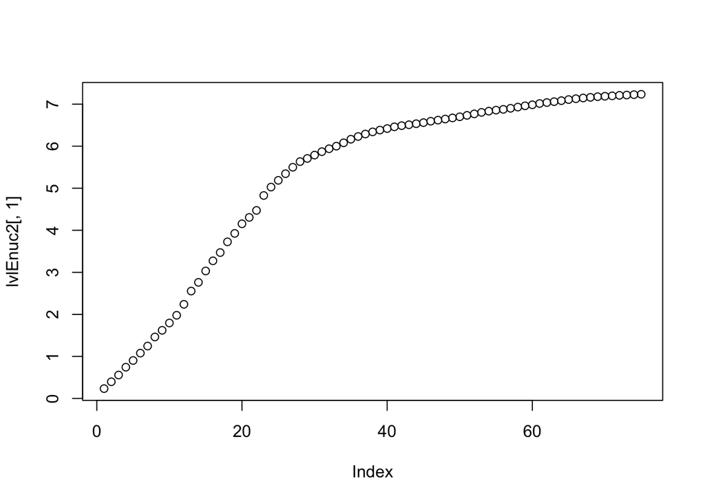

```r
plot(lvlEnuc2[, 1])
```

Confirmed that this gives us a cumulative sum.

```r
lvlEnucStates <- ts(1+lvlEnuc2, firstYear+1)
str(lvlEnucStates)
```

```
##  Time-Series [1:75, 1:2500] from 1946 to 2020: 1.23 1.4 1.56 1.74 1.9 ...
##  - attr(*, "dimnames")=List of 2
##   ..$ : NULL
##   ..$ : chr [1:2500] "Series 1" "Series 2" "Series 3" "Series 4" ...
```

```r
lvlMean <- ts(apply(lvlEnucStates, 1, mean),
                    firstYear+1)
str(lvlMean)
```

```
##  Time-Series [1:75] from 1946 to 2020: 1.17 1.34 1.52 1.7 1.87 ...
```

```r
lvlQuant <- ts(t(apply(lvlEnucStates, 1,
      quantile, probs=c(0.025, .5, .975))),
                    firstYear+1)
str(lvlQuant)
```

```
##  Time-Series [1:75, 1:3] from 1946 to 2020: 1.05 1.1 1.16 1.22 1.28 ...
##  - attr(*, "dimnames")=List of 2
##   ..$ : NULL
##   ..$ : chr [1:3] "2.5%" "50%" "97.5%"
```

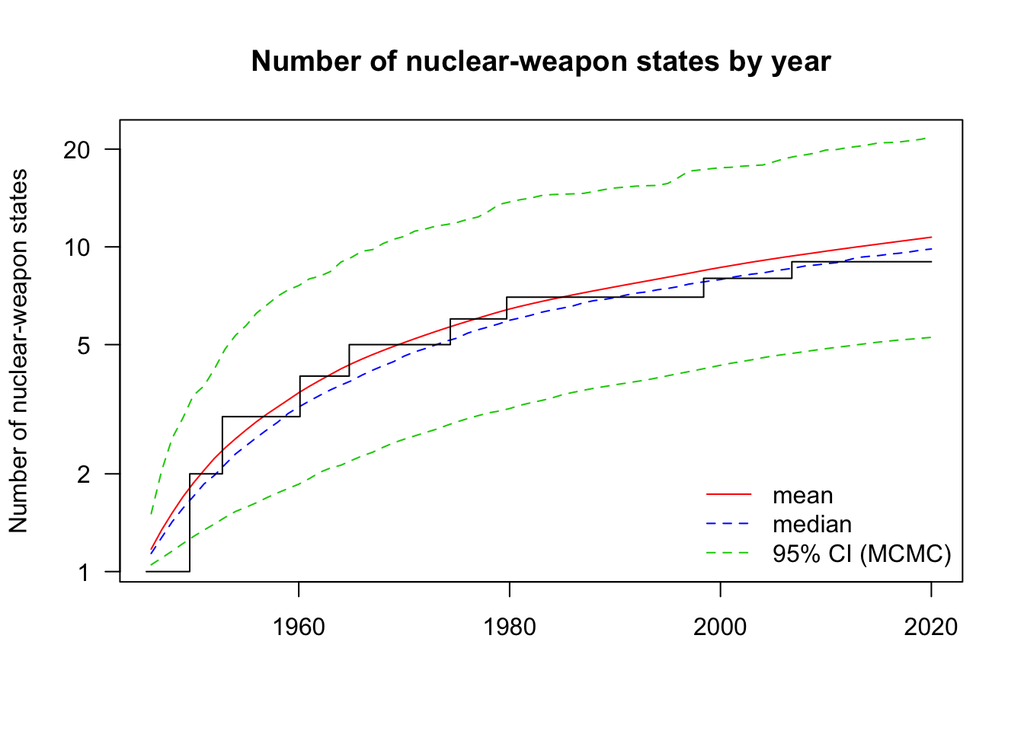

```r
ts.plot(lvlMean, lvlQuant,
    col=c(2, 3, 4, 3),
    lty=c(1, 2, 2, 2), log='y',
    gpars=list(las=1), xlab='',
    ylab='Number of nuclear-weapon states',
    main=paste('Number of nuclear-weapon',
               'states by year') )

legend('bottomright',
  legend=c('mean',
    'median',
    '95% CI (MCMC)'),
  col=c(2, 4, 3),
  lty=c(1, 2, 2), bty='n')

fT_date <- c(nuclearWeaponStates$firstTestYr,
             currentYear+1)
nNucStates <- nrow(nuclearWeaponStates)
lines(fT_date,
    c(1:nNucStates, nNucStates), type='s')
```

The upper and lower limits display the range of plausibilty for trajectories of the meanes of Poisson processes consistent with the available data: Lines below the lower limit would not likely have produced as many nuclear-weapon states during this period as we have today. Lines above the upper limit likely would have produced more than the number that exists today.

The median goes right through the available data. The mean looks a little high. Overall this looks like a great fit, apart from the fact that all the increments decrease log(Poisson mean). For that we should consider adding a slope term to the model, which we consider next.

# Growing understanding of the risks

The model considered so far assumes a Gaussian random walk in one dimension.

The last plot suggest we consider adding another term, linear in log(time since the very first test of a nuclear weapon by the US).

Before trying a more sophisticated model, let’s plot the estimated trend above by itself to see if that supports adding log(time since the very first test of a nuclear weapon by the US) to the model.

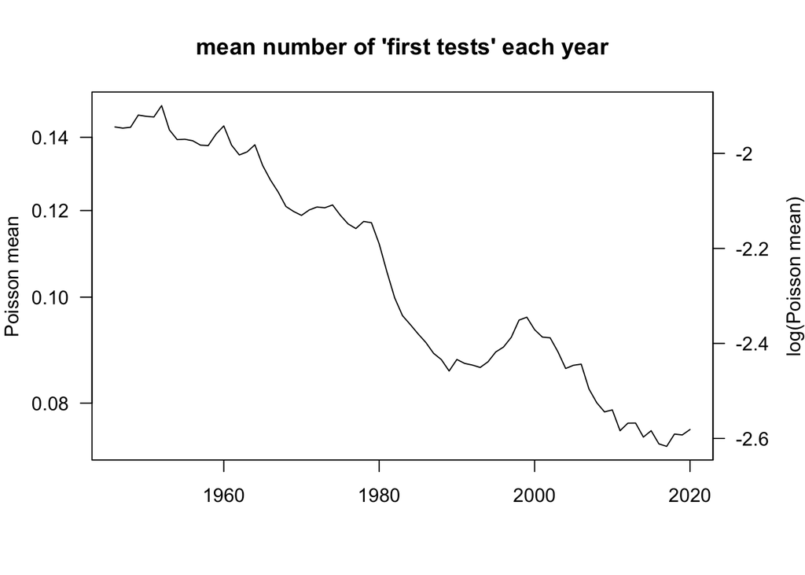

```r
op <- par(mar=c(5,4,4,4))
ts.plot(exp(lvl), gpars=list(las=1),
      xlab='', ylab='Poisson mean',
      main=paste("mean number of 'first tests'",
          "each year"), log='y')

# add a scale for log(Poisson mean)
lvlLim1 <- range(lvl)
lvlLogTick1 <- pretty(lvlLim1)
axis(4, exp(lvlLogTick1), lvlLogTick1,
     las=1)
mtext('log(Poisson mean)', 4, 3)
```

```r
par(op)
```

The plot of log(Poisson rate) vs. time encourages us to consider adding time as a linear term. A state-space model that is essentially equivalent has a slope term.

The same [`ng_bsm` function](https://www.rdocumentation.org/packages/bssm/versions/0.1.7/topics/ng_bsm) used above includes an `sd_slope` argument, which is “A fixed value or a prior for the standard error of the noise in slope equation.” Let’s specify that as a normal with mean 0 and standard deviation being the root mean square increments in the estimate of level in the level-only model above:

```r
firstTstsLin <- ng_bsm(FirstTests$nFirstTests,
    sd_level=halfnormal(sd_lvl, 10*sqrt(P1)),
    sd_slope=normal(0, 0, sd_lvl),
    a1=c(a1, -sd_lvl), P1=P1*diag(c(1, 100)),
    distribution='poisson')
str(firstTstsLin)
```

```
## List of 23
##  $ y                  : Time-Series [1:74] from 1946 to 2019: 0 0 0 1 0 0 1 0 0 0 ...
##  $ Z                  : num [1:2, 1] 1 0
##   ..- attr(*, "dimnames")=List of 2
##   .. ..$ : chr [1:2] "level" "slope"
##   .. ..$ : NULL
##  $ T                  : num [1:2, 1:2, 1] 1 0 1 1
##   ..- attr(*, "dimnames")=List of 3
##   .. ..$ : chr [1:2] "level" "slope"
##   .. ..$ : chr [1:2] "level" "slope"
##   .. ..$ : NULL
##  $ R                  : num [1:2, 1:2, 1] 0.169 0 0 0
##   ..- attr(*, "dimnames")=List of 3
##   .. ..$ : chr [1:2] "level" "slope"
##   .. ..$ : NULL
##   .. ..$ : NULL
##  $ a1                 : Named num [1:2] -1.253 -0.169
##   ..- attr(*, "names")= chr [1:2] "level" "slope"
##  $ P1                 : num [1:2, 1:2] 3.5 0 0 350
##   ..- attr(*, "dimnames")=List of 2
##   .. ..$ : chr [1:2] "level" "slope"
##   .. ..$ : chr [1:2] "level" "slope"
##  $ phi                : num 1
##  $ u                  : num [1:74] 1 1 1 1 1 1 1 1 1 1 ...
##  $ xreg               : num[0 , 0 ]
##  $ coefs              : num(0)
##  $ obs_intercept      : num [1, 1] 0
##  $ state_intercept    : num [1:2, 1] 0 0
##  $ slope              : logi TRUE
##  $ seasonal           : logi FALSE
##  $ noise              : logi FALSE
##  $ period             : num 1
##  $ fixed              : int [1:3] 0 0 1
##  $ distribution       : chr "poisson"
##  $ initial_mode       : Time-Series [1:74] from 1946 to 2019: -2.3 -2.3 -2.3 0 -2.3 ...
##  $ prior_distributions: num [1:2] 1 2
##  $ prior_parameters   : num [1:2, 1:2] 18.708 NA 0 0.169
##  $ theta              : Named num [1:2] 0.169 0
##   ..- attr(*, "names")= chr [1:2] "sd_level" "sd_slope"
##  $ phi_est            : logi FALSE
##  - attr(*, "class")= chr [1:2] "ng_bsm" "ngssm"
```

Let’s proceed to estimate parameters as before:

```r
set.seed(2)
firstTstsSim2 <- run_mcmc(firstTstsLin,
          nsim_states=2, n_iter = 5000)
firstTstsSim2
```

```
##
## Call:
## run_mcmc.ng_bsm(object = firstTstsLin, n_iter = 5000, nsim_states = 2)
##
## Iterations = 2501:5000
## Thinning interval = 1
## Length of the final jump chain = 1
##
## Acceptance rate after the burn-in period:  0
##
## Summary for theta:
##
##               Mean SD SE
## sd_level 0.1718563  0  0
## sd_slope 0.0000000  0  0
##
## Effective sample sizes for theta:
##
##          ESS
## sd_level NaN
## sd_slope NaN
##
## Summary for alpha_75:
##
##              Mean SD SE
## level -3.87021414  0  0
## slope -0.05327772  0  0
##
## Effective sample sizes for alpha_75:
##
##       ESS
## level NaN
## slope NaN
##
## Run time:
##    user  system elapsed
##   0.003   0.000   0.003
```

This says, “Acceptance rate after the burn-in period: 0”. Let’s try to tighten the prior:

```r
firstTstsLin2 <- ng_bsm(FirstTests$nFirstTests,
    sd_level=halfnormal(sd_lvl, 0.1*sqrt(P1)),
    sd_slope=normal(0, 0, 0.1*sd_lvl),
    a1=c(a1, -sd_lvl), P1=0.01*P1*diag(c(1, 1)),
    distribution='poisson')
#str(firstTstsLin2)
```

Let’s proceed to estimate parameters as before:

```r
set.seed(3)
firstTstsSim2a <- run_mcmc(firstTstsLin,
          nsim_states=2, n_iter = 5000)
firstTstsSim2a
```

```
##
## Call:
## run_mcmc.ng_bsm(object = firstTstsLin, n_iter = 5000, nsim_states = 2)
##
## Iterations = 2501:5000
## Thinning interval = 1
## Length of the final jump chain = 1
##
## Acceptance rate after the burn-in period:  0
##
## Summary for theta:
##
##               Mean SD SE
## sd_level 0.1962307  0  0
## sd_slope 0.0000000  0  0
##
## Effective sample sizes for theta:
##
##          ESS
## sd_level NaN
## sd_slope NaN
##
## Summary for alpha_75:
##
##              Mean SD SE
## level -4.31686626  0  0
## slope -0.03914561  0  0
##
## Effective sample sizes for alpha_75:
##
##       ESS
## level NaN
## slope NaN
##
## Run time:
##    user  system elapsed
##   0.002   0.000   0.003
```

We therefore return to the first model and see what predictions we can get from that.

# Predict

Let’s use the 74 years of history available in late 2019 to predict another 74 years into the future. For this, we use predict.mcmc_output. We start by producing a `future_model`, as in the example in the help page and the `bssm` vignette:

```r
firstTstsFutureMdl <- firstTstsMdl
firstTstsFutureMdl$y <- ts(rep(NA, 74),
                    start=currentYear+1)
```

```r
set.seed(4)
firstTstsPred_r <- try(predict(firstTstsSim,
      firstTstsFutureMdl,
      return_MCSE = TRUE))
str(firstTstsPred_r)
```

```
## List of 2
##  $ mean     : Time-Series [1:74] from 2020 to 2093: 0.113 0.105 0.107 0.111 0.107 ...
##  $ intervals: Time-Series [1:74, 1:3] from 2020 to 2093: 0 0 0 0 0 0 0 0 0 0 ...
##   ..- attr(*, "dimnames")=List of 2
##   .. ..$ : NULL
##   .. ..$ : chr [1:3] "5%" "50%" "95%"
##  - attr(*, "class")= chr "predict_bssm"
```

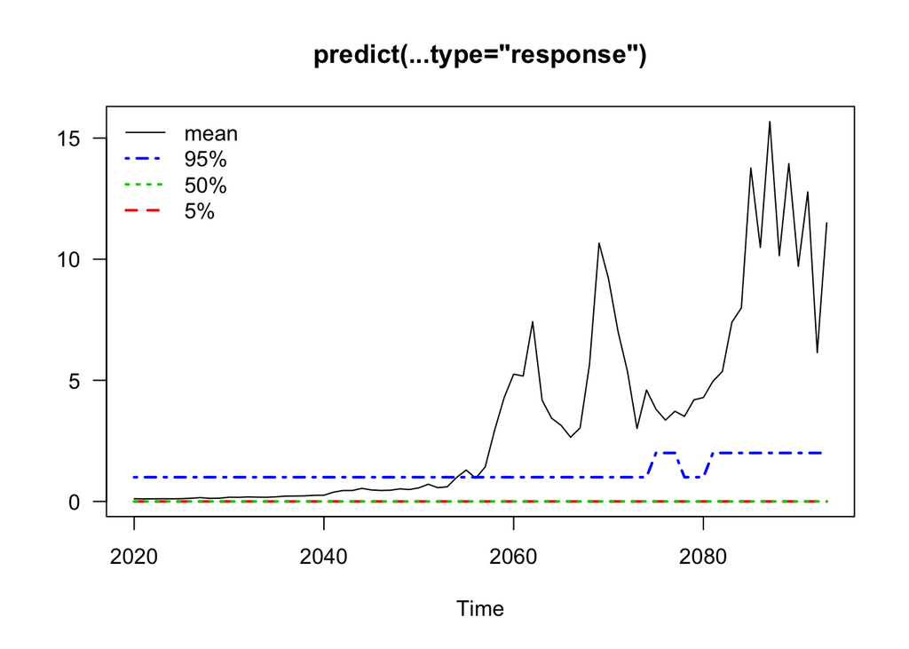

```r
with(firstTstsPred_r, ts.plot(
  mean, intervals, gpars=list(las=1),
  main='predict(...type="response")',
  col=1:4, lty=1:4, lwd=c(1,2,2,2)) )
legend('topleft',
  legend=c('mean', "95%", "50%", "5%"),
  col=c(1, 4:2), lty=c(1, 4:2),
  lwd=c(1,2,2,2), bty='n')
```

```r
firstTstsPred_m <- try(predict(firstTstsSim,
      type='mean', firstTstsFutureMdl,
      return_MCSE = TRUE))
str(firstTstsPred_m)
```

```
## List of 2
##  $ mean     : Time-Series [1:74] from 2020 to 2093: 0.105 0.108 0.113 0.116 0.122 ...
##  $ intervals: Time-Series [1:74, 1:3] from 2020 to 2093: 0.0157 0.0155 0.0151 0.0144 0.0138 ...
##   ..- attr(*, "dimnames")=List of 2
##   .. ..$ : NULL
##   .. ..$ : chr [1:3] "5%" "50%" "95%"
##  - attr(*, "class")= chr "predict_bssm"
```

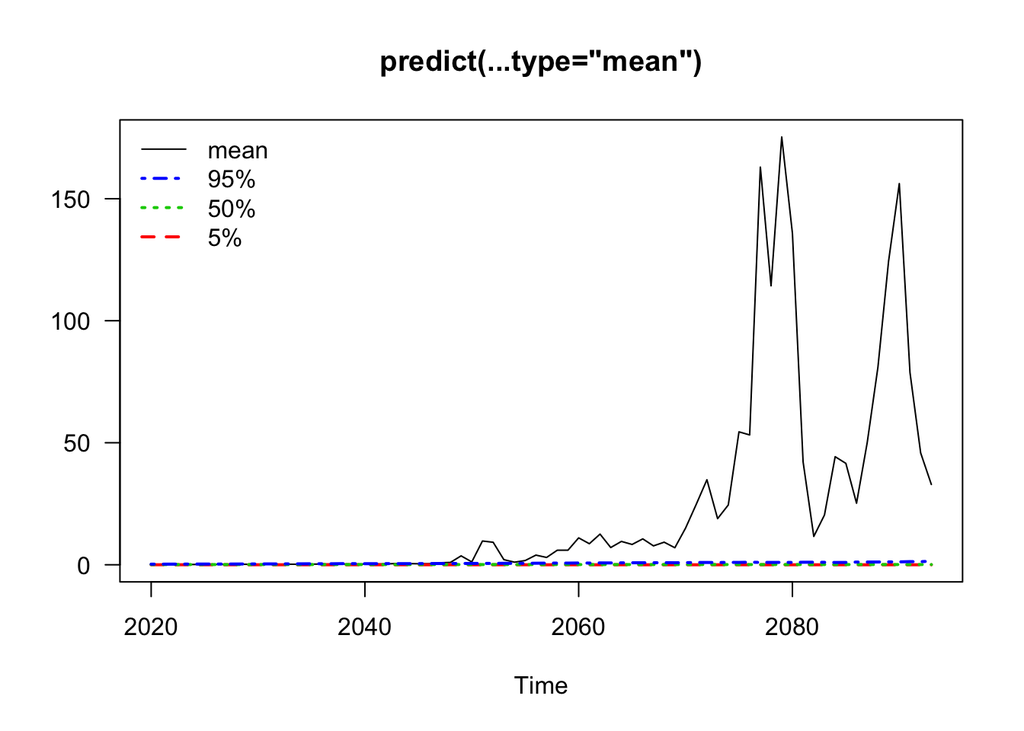

```r
with(firstTstsPred_m, ts.plot(
  mean, intervals, gpars=list(las=1),
  main='predict(...type="mean")',
  col=1:4, lty=1:4, lwd=c(1, 2,2,2)) )
legend('topleft',
  legend=c('mean', "95%", "50%", "5%"),
  col=c(1, 4:2), lty=c(1, 4:2),
  lwd=c(1,2,2,2), bty='n')
```

```r
firstTstsPred_s <- try(predict(firstTstsSim,
      type='state', firstTstsFutureMdl,
      return_MCSE = TRUE))
str(firstTstsPred_s)
```

```
## List of 2
##  $ mean     : Time-Series [1:74, 1] from 2020 to 2093: -2.58 -2.59 -2.58 -2.58 -2.58 ...
##   ..- attr(*, "dimnames")=List of 2
##   .. ..$ : NULL
##   .. ..$ : chr "level"
##  $ intervals:List of 1
##   ..$ level: Time-Series [1:74, 1:3] from 2020 to 2093: -4.15 -4.25 -4.21 -4.27 -4.35 ...
##   .. ..- attr(*, "dimnames")=List of 2
##   .. .. ..$ : NULL
##   .. .. ..$ : chr [1:3] "5%" "50%" "95%"
##  - attr(*, "class")= chr "predict_bssm"
```

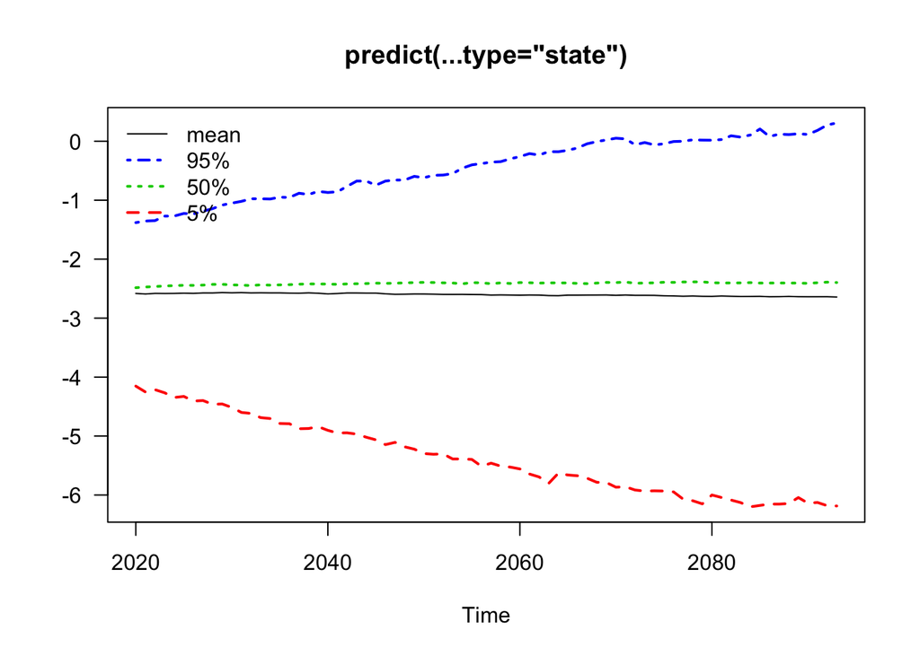

```r
with(firstTstsPred_s, ts.plot(
  mean, intervals$level,
  gpars=list(las=1),
  main='predict(...type="state")',
  col=1:4, lty=1:4, lwd=c(1,2,2,2)) )
legend('topleft',
  legend=c('mean', "95%", "50%", "5%"),
  col=c(1, 4:2), lty=c(1, 4:2),
  lwd=c(1,2,2,2), bty='n')
```

It’s not obvious what type = “response” or “mean” are in this context, but type = “state” seems potentially useful.

However, we really want the cumsum(annual Poisson counts). To get that, it would be easiest if we had simulated trajectories of log(Poisson means of annual counts). Then we could compute cumsum(exp(log(Poisson means))) and compute mean and quantiles from those numbers.

From that, we could estimate the probability of 0, 1, 2, or more currently non-nuclear states (or non-state rebel groups) becoming nuclear as a function of the time into the future.

We will construct these manually in two different ways:

- Assuming the annual changes in log(Poisson mean number of new nuclear-weapon states each year) have mean 0 and standard deviation given by the estimate of `theta` in each accepted MCMC simulation.
- Using the estimated first differences from the level-only model.

The first gives pessimistic estimates, basically assuming that the trend toward decreasing hazard showing in the plots in the introduction above could be reversed by a new arms race exemplified by the current nuclear expansion programs in India, Pakistan, the US,[^13] and Russia as well as the declared desire of the President of Turkey for nuclear weapons[^14] and the increased threat that such weapons could fall into the hands of terrorists who believe that Armageddon may be a good thing, for whom the possession of nuclear weapons is more of a motivator than a deterrent.[^15]

The second essentially assumes a continuation of the trend visible in the plots above showing gradual reductions in the rate of nuclear proliferation.

We will examine these two alternative simulations in the order stated, recognizing that the reality could be some in between with a nonzero probability of the elimination of the threat through the entering into force of the International Treaty on the Abolition of Nuclear Weapons, followed by the success of other more aggressive efforts to strengthen international law to the point that any nation that invades another can expect massive nonviolent retaliation in trade restrictions and confiscation of foreign held property of people in the nation of the apparent aggressor(s).

# Predictions assuming the level-only model

Our primary model estimated in `firstTstsSim` assumes that log(Poisson mean) follows a random walk with independent annual increments of mean 0 and standard deviation `theta`. Our approach here will iterate over all 2500 accepted simulations after burn-in, matching the log(Poisson mean[2020]) from `firstTstsSims$level[i, 75]` with the estimate of the corresponding standard deviation in theta[i, 1]:

```r
manPred <- ts(matrix(NA, 75, 2500),
    start=currentYear+1)

manPred[1, ] <- (firstTstsSims$level[,
      75] + rnorm(75, 0, theta[, 1]) )
for(iyr in 2:75){
  manPred[iyr, ] <- (manPred[iyr-1, ] +
        rnorm(2500, 0, theta[, 1]) )
}
```

Next we want to exponentiate these numbers and cumsum each row to get the expected number of new nuclear-weapon states for each simulated future year:

```r
str(predEnuc2 <- ts(apply(exp(manPred), 2,
          cumsum), currentYear+1) )
```

```
##  Time-Series [1:75, 1:2500] from 2020 to 2094: 0.0103 0.0188 0.0308 0.0432 0.0529 ...
##  - attr(*, "dimnames")=List of 2
##   ..$ : NULL
##   ..$ : chr [1:2500] "Series 1" "Series 2" "Series 3" "Series 4" ...
```

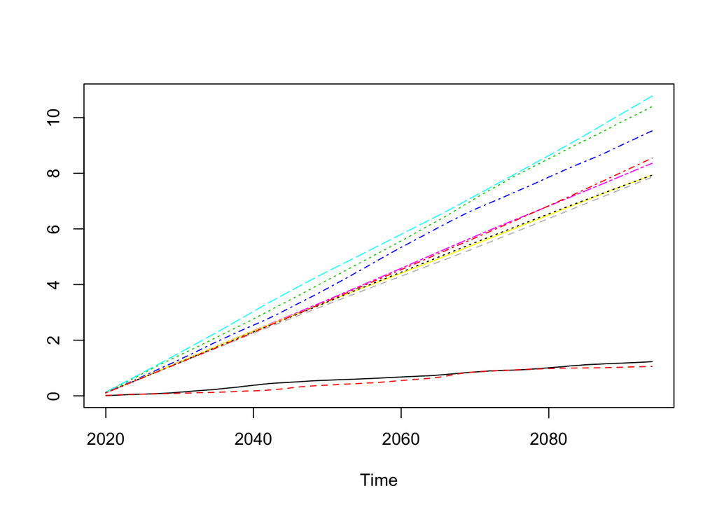

```r
ts.plot(predEnuc2[, 1:10], lty=1:10, col=1:10)
```

Now let’s add the current nuber of nuclear weapon states, 9 as this is being written on 2019-11-02, to predict the total number of nuclear-weapon states for the next 74 years:

```r
predEnucStates <- (9+lvlEnuc2)
predEnucStates <- ts(9+lvlEnuc2,
                  currentYear+1)
str(predEnucStates)
```

```
##  Time-Series [1:75, 1:2500] from 2020 to 2094: 9.23 9.4 9.56 9.74 9.9 ...
##  - attr(*, "dimnames")=List of 2
##   ..$ : NULL
##   ..$ : chr [1:2500] "Series 1" "Series 2" "Series 3" "Series 4" ...
```

```r
predMean <- ts(apply(predEnucStates,
        1, mean), currentYear+1)
str(predMean)
```

```
##  Time-Series [1:75] from 2020 to 2094: 9.17 9.34 9.52 9.7 9.87 ...
```

```r
predQ <- apply(predEnucStates, 1,
    quantile, probs=c(0.05, .5, .95))
predQuant <- ts(t(predQ),
                currentYear+1)
str(predQuant)
```

```
##  Time-Series [1:75, 1:3] from 2020 to 2094: 9.06 9.11 9.17 9.23 9.3 ...
##  - attr(*, "dimnames")=List of 2
##   ..$ : NULL
##   ..$ : chr [1:3] "5%" "50%" "95%"
```

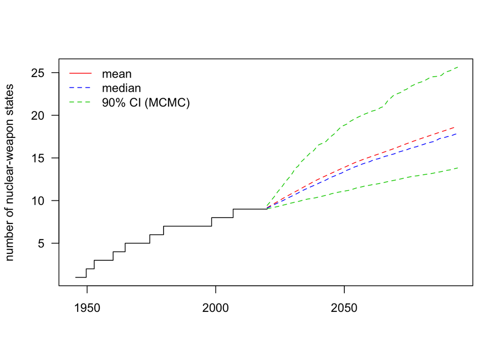

```r
yLab <- 'number of nuclear-weapon states'
plot(c(firstYear, currentYear+75),
     c(1, max(predQuant)), type='n',
     xlab='', ylab=yLab, las=1)
lines(fT_date,
    c(1:nNucStates, nNucStates), type='s')
lines(predMean, lty=2, col=2)

predYrs <- time(predQuant)
matlines(predYrs, predQuant, lty=2,
      col=c(3, 4, 3) )

legend('topleft',
  legend=c('mean',
    'median',
    '90% CI (MCMC)'),
  col=c(2, 4, 3),
  lty=c(1, 2, 2), bty='n')
```

The model assumes that the `log(level[i])`, where `i` = a year after 2020, is based on the following recursion:

`log(Poisson mean[i+1]) = log(Poisson[i]) + (independent random increment)`.

The mean of the independent increments is 0 with a standrd deviation given by the posterior distribution of the variable `theta` described above.

Let’s start by selecting nYrs from the available MCMC simulations after burn-in:

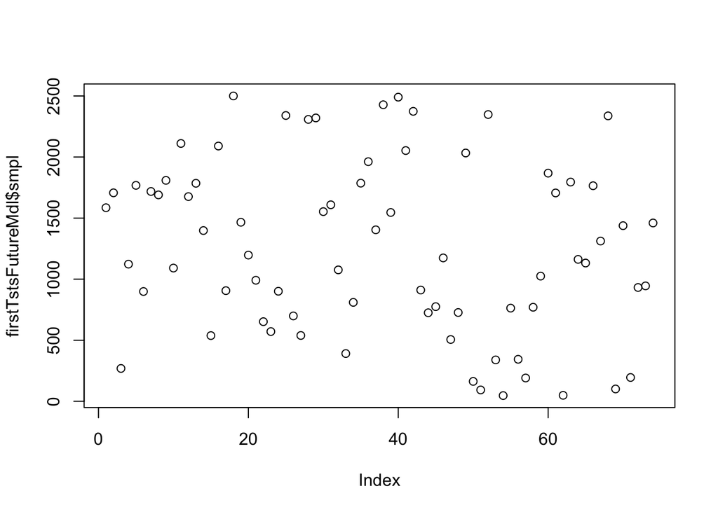

```r
firstTstsFutureMdl$smpl <- sample(
  with(firstTstsSim, n_iter - n_burnin),
  nYrs)
plot(firstTstsFutureMdl$smpl)
```

We select MCMC samples this way, in case there’s a relationship between the MCMC simulations in `theta` and `alpha` stored in `firstTstsSim`, above.

Now let’s select the log(Poisson mean) for each predicted year from the distribution for `(currentYear+1)`:

```r
firstTstsFutureMdl$simLevel <- ts(
  lvlAll$level[firstTstsFutureMdl$smpl,
        nYrs+1], currentYear+1)
```

Let’s similary select the standard deviation of these estimated levels from `theta`:

```r
firstTstsFutureMdl$simSD <- ts(
  theta[firstTstsFutureMdl$smpl, 1],
  currentYear+1)
```

Now let’s predict the future mean number of nuclear-weapon states by adding `cumsum(exp(firstTstsFutureMdl$simLevel))` to the current number of nuclear-weapon states:

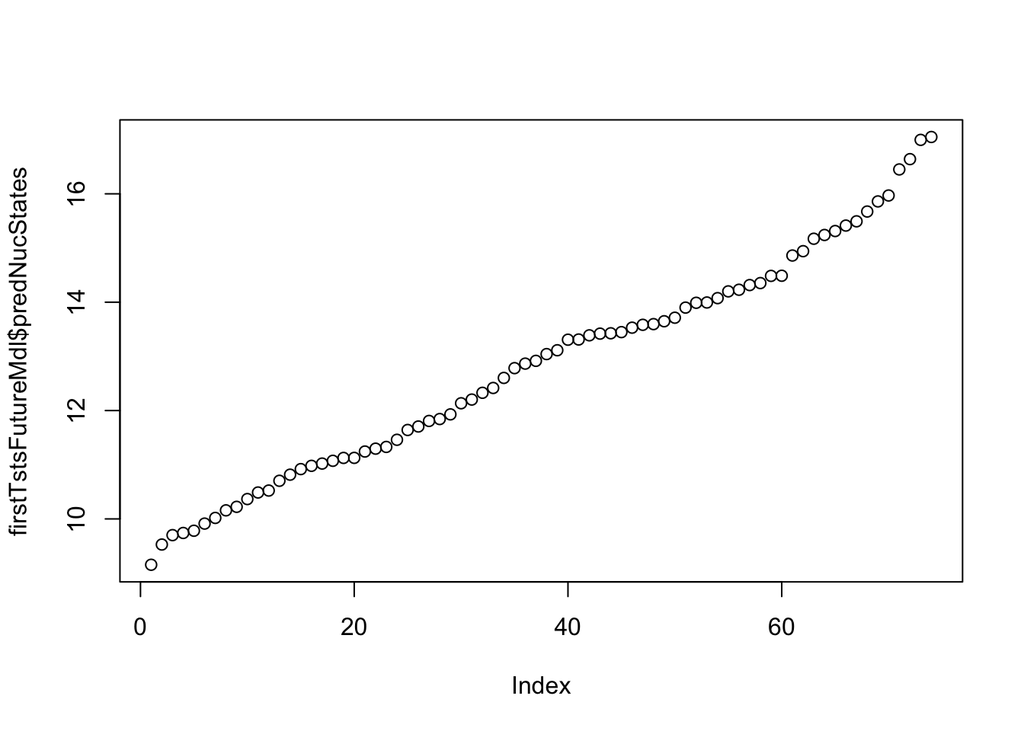

```r
firstTstsFutureMdl$predNucStates <-
  nrow(nuclearWeaponStates) + cumsum(exp(
    firstTstsFutureMdl$simLevel))
plot(firstTstsFutureMdl$predNucStates)
```

# Conclusions

# Appendix. Plotting to a file

Plotting the time between first tests to a file was surprisingly difficult, because font sizes in the files were smaller than the standard display, and getting larger fonts was surprisingly difficult. Consider the following:

```r
if(FALSE){
  png('nuclearProliferation.png', 1440, 1200)
  par(mar=c(15, 12, 4, 2)+.1)
  plot(yearsSinceLastFirstTest~firstTest,
     nuclearWeaponStates, type='h',
     xlab='', ylab='', las=1, cex.axis=4,
     bty='n', axes=FALSE, lwd=2,
     ylim=ylim.)
  xyr <- seq(1950, 2000, 10)
  xt. <- paste0(xyr, '-01-01')
  xticks <- as.Date(xt.)
  axis(1, xticks, labels=FALSE, lwd=2)
  axis(1, xticks, xyr, cex.axis=4, lwd=0, line=2)
#axis(1, seq(1950, 2000, by=10), cex.axis=4, lwd=0, line=1)
  axis(2, cex.axis=4, las=1, lwd=2)
  title('Time between new nuclear nations',
      cex.main=4)
  mtext(paste0(
    'Note: The US is not on this plot,',
    '\nbecause it had no predecessors.'),
        1, 12, cex=4)
  mtext('years from the\nprevious "first test"',
      2, 5, cex=4)
  with(nuclearWeaponStates,
    text(firstTest, yearsSinceLastFirstTest,
       ctry, xpd=TRUE, cex=4))
  dev.off()
}
```

Plot to an svg file, killing the labels for Wikimedia Commons:

```r
if(FALSE){
  svg('nuclearProliferation.svg', 14, 11)
  Label. <- FALSE
  par(mar=c(9, 8, 4, 2)+.1)
  cex. <- 4
  plot(yearsSinceLastFirstTest~firstTest,
     nuclearWeaponStates, type='h',
     xlab='', ylab='', axes=FALSE,
     bty='n', ylim=ylim.)
#  axis(1, cex.axis=cex., line=1)
  axis(1, labels=FALSE)
  axis.Date(1,
    nuclearWeaponStates$firstTest,
    tick=FALSE, cex.axis=cex., line=2)
  axis(2, cex.axis=cex., las=1)
  if(Label.)title(
    'Time between new nuclear nations',
                  cex.main=2)
  noUS <- paste0(
    'Note: The US is not on this plot,',
    '\nbecause it had no predecessors.')
  if(Label.)mtext(noUS, 1, 6, cex=cex.)
  ylab. <- paste(
    'years from the\nprevious "first test"')
  if(Label.)mtext(ylab., 2, 4, cex=cex.)
  with(nuclearWeaponStates,
    text(firstTest, yearsSinceLastFirstTest,
       ctry, xpd=TRUE, cex=cex.))
  dev.off()
}
```

Plot to png, killing the labeling for Wikimedia Commons

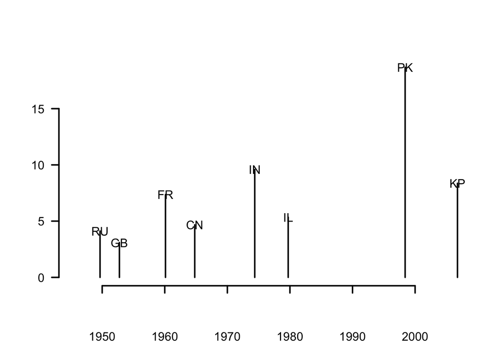

```r
ymax <- max(nuclearWeaponStates$yearsSinceLastFirstTest,
            na.rm=TRUE)
ylim. <- c(0, ymax)

png. <- FALSE
cex.ax=1
lbl <- TRUE
if(png.){
    png('nuclearProliferation.png', 1440, 1200)
  if(lbl){
#    par(mar=c(15, 15, 7, 2)+.1)
    par(mar=c(15, 15, 2, 2)+.1)
  } else par(mar=c(5, 5, 2, 2)+.1)
    cex.ax=4
}
plot(yearsSinceLastFirstTest~firstTest,
     nuclearWeaponStates, type='h',
     xlab='', ylab='', las=1, cex.axis=cex.ax,
     bty='n', axes=FALSE, lwd=2, ylim=ylim.)
if(lbl){
#  title('Figure 1. Time between\nnew nuclear nations',
#    cex.main=cex.ax)
  xlab. <- paste(c('Note: The US is not on this plot,',
                   'because it had no predecessors.'),
                 collapse='\n')
  mtext(xlab., 1, 11, cex=cex.ax)
  mtext('years from the\nprevious "first test"',
        2, 6, cex=cex.ax)
}
xyr <- seq(1950, 2000, 10)
xt. <- paste0(xyr, '-01-01')
xticks <- as.Date(xt.)
axis(1, xticks, labels=FALSE, lwd=2)
axis(1, xticks, xyr, cex.axis=cex.ax, lwd=0, line=2)
#axis(1, seq(1950, 2000, by=10), cex.axis=4, lwd=0, line=1)
axis(2, cex.axis=cex.ax, las=1, lwd=2)
#  title('Time between new nuclear nations', cex.main=4)
xlab. <- paste0('Note: The US is not on this plot,',
    '\nbecause it had no predecessors.')
#  mtext(xlab., 1, 12, cex=4)
ylab. <- paste0('Note: The US is not on this plot,',
    '\nbecause it had no predecessors.')
#  mtext(ylab., 1, 12, cex=4)

with(nuclearWeaponStates,
    text(firstTest, yearsSinceLastFirstTest,
       ctry, xpd=TRUE, cex=cex.ax))
```

```r
if(png.) dev.off()
```